# Intermediate R for social science

## Facets

- So far we have been visualizing grouped data by changing the appearance or position of the objects.
- A different approach is to use facets, which creates separate coordinate systems for each geometric object.

## Example: Comparing generation patterns

Task:  
Compare energy generation over time, across sources.

How do we do this? Using what we’ve learned so far:

1. Supply `ca_energy_long` to `ggplot()`.
2. Add a `geom_line()` layer, setting `x=datetime` and `y=output` in `aes()`.
3. Let’s set `group=source` and `col=source` in `aes()`.

## Example: Comparing generation patterns

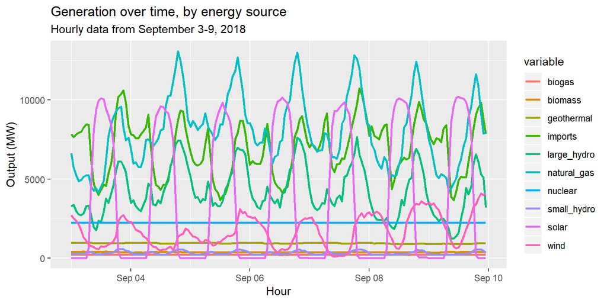

```r
ca_energy_long %>%
  ggplot() +
  geom_line(aes(x=datetime, y=value, group=variable, col=variable), size=1) +
  labs(title="Generation over time, by energy source", subtitle="Hourly data from September 3-9, 2018", x="Hour", y="Output (MW)")
```

## Example: Comparing generation patterns

Is this a helpful plot?

- Not if our goal is to compare the patterns of each source.
- It’s too noisy!
- Instead of setting `col=` in `aes()`, let’s add a `facet_wrap()` layer.
- Specifically, `facet_wrap(~variable)`, i.e. tell ggplot to “facet by variable”.

## Example: Comparing generation patterns

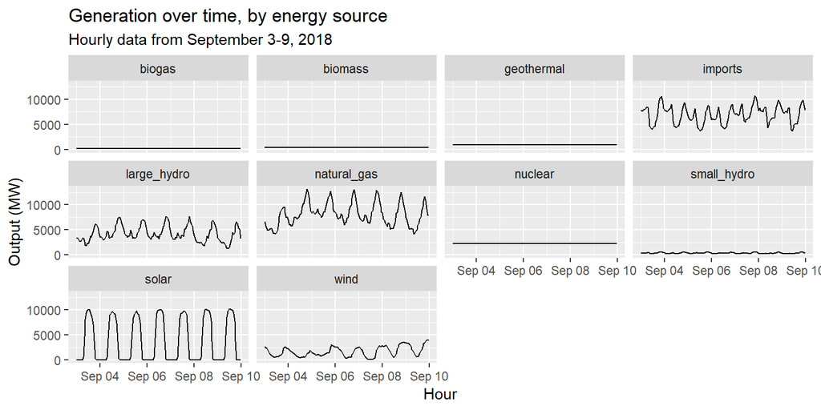

```r
ca_energy_long %>%
  ggplot() +
  geom_line(aes(x = datetime, y = value)) +
  facet_wrap(~variable) +
  labs(title="Generation over time, by energy source", subtitle="Hourly data from September 3-9, 2018", x="Hour", y="Output (MW)")
```

## Example: Comparing generation patterns

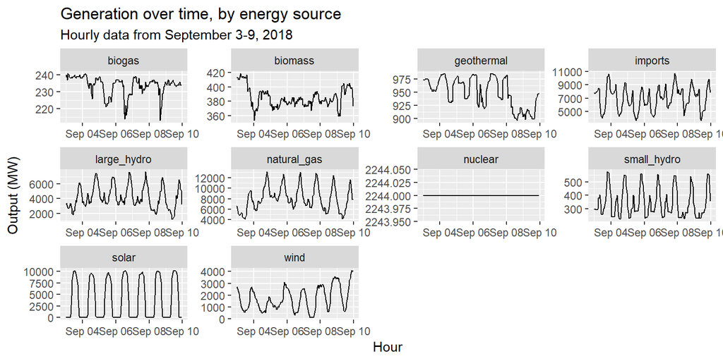

```r
ca_energy_long %>%
  ggplot() +
  geom_line(aes(x = datetime, y = value)) +
  facet_wrap(~variable, scales="free") +
  labs(title="Generation over time, by energy source", subtitle="Hourly data from September 3-9, 2018", x="Hour", y="Output (MW)")
```

## Exercise 6: Facets

Task:  
Compare generation patterns for each source in facets. Color the lines using the “group” variable in `ca_groups`.

Remember:

- Import the `ca_groups` data from your data folder and examine it.
- You will need to merge the groups data and the long energy data such that each row has a “group” variable that matches the energy source type.
- When you pipe modified data into ggplot, remember that you are grouping in two ways: faceting by source type and coloring by the new “group” variable.

## Exercise 6: Facets

```r
ca_groups <- read_csv("data/ca_groups.csv")
ca_energy_long_groups <- merge(ca_energy_long, ca_groups, by.x="variable", by.y="type")
```

## Exercise 6: Facets

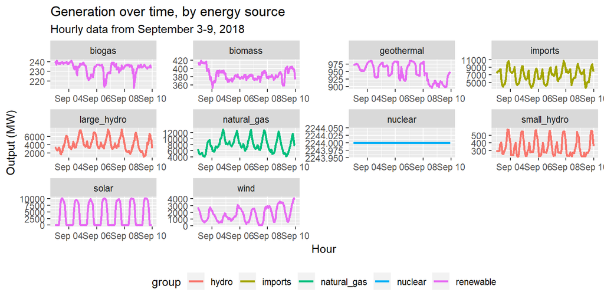

```r
ca_energy_long_groups %>% ggplot() +
  geom_line(aes(x=datetime, y=value, group=group, col=group), size=1) +
  facet_wrap(~variable, scales="free") +
  labs(title="Generation over time, by energy source", subtitle="Hourly data from September 3-9, 2018", x="Hour", y="Output (MW)") +
  theme(legend.position = "bottom")
```

## Final notes

- Always remember to comment your code! When writing particularly complex code in `dplyr` or `ggplot2`, this includes commenting *within* a flow of `%>%` or `+` operators. See the lecture notes for some examples of this.
- You can save a plot in two ways: using the “save” icon in the Plots tab of RStudio, or adding `ggsave()` as a layer to your plotting code.